# Lab 8: Transformations

2020-11-04

Sometimes, our data will not follow a linear relationship on the original scale, but an (approximate) linear relationship can be induced through a transformation.

First: two rules of thumb. **Log rule.** If values range over more than one order of magnitude, a log transformation can often be helpful (consider how this can affect leverage).

**Range rule.** If the range of a variable is considerably less than one order of magnitude, tranformations may not be helpful.

This is a good starting point to set our expectations, but we need more systematic ways to choose transformations.

## Simple case: Transforming $X$ with only one predictor

For simple regression with a single predictor, we may use invTranPlot in the car package (Companion to Applied Regression) to determine a proper transformation. Our goal is to make the mean function linear after some transformation $\Psi_S(X,\lambda)$:
$$E(Y\mid X) \approx \beta_0 + \beta_1\Psi_S(X,\lambda).$$
This can be easily done because we only have one $X$.

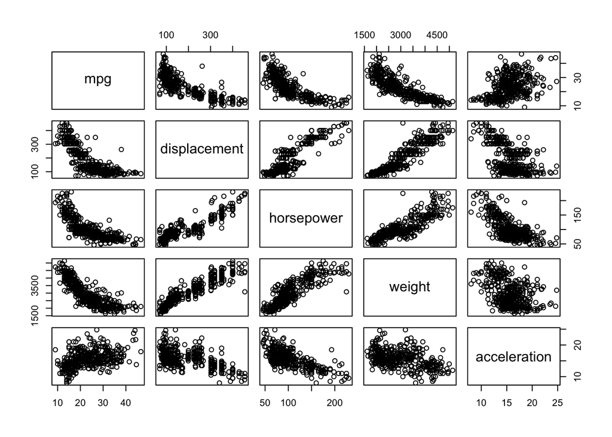

```r
library(alr4)
library(car)

data(Auto)
# subset to continuous, positive predictors of mpg
Auto <- Auto %>% select(mpg,displacement,horsepower,weight,acceleration)

# look at the pairs plot
pairs(Auto)
```

None of these variables violate the range rule, but we do see some non-linearities in their relationships with our response mpg.

### invTranPlot

Suppose we are interested in predicting `mpg` with only `horsepower`.

invTranPlot will produce a scatter plot of the chosen variables and plot the least squares line for different choices of $\lambda$ in the scaled power transformation:
$$\Psi_{S}(X,\lambda) = \frac{X^{\lambda}-1}{\lambda}.$$

Note that
$$\lim_{\lambda \rightarrow 0} \frac{X^{\lambda}-1}{\lambda} = \log(X).$$
Typically $\lambda \in [-2,2]$.

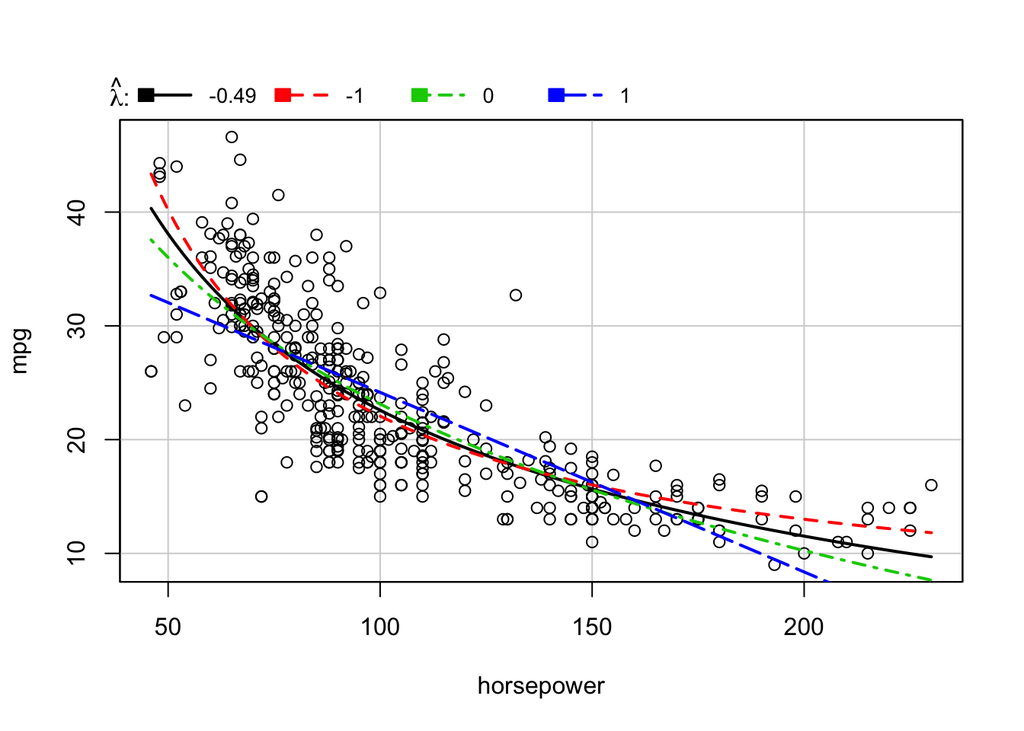

```r
# basic syntax is invTranPlot(y~x,data=data)
# NOTE this will produce a plot and a data frame

itp <- invTranPlot(mpg~horsepower,data=Auto)
```

```r
itp
```

```
##       lambda      RSS
## 1 -0.4852651 7701.809
## 2 -1.0000000 7929.141
## 3  0.0000000 7899.932
## 4  1.0000000 9385.916
```

```r
# invTranPlot only works for a single predictor - it will throw an error if you try and use more than one.
```

From this data we might choose $\hat{\lambda} = -0.5$, and fit a regression of the response mpg on 1/sqrt(horsepower). The choice of lambda does not need to perfect, and choosing $\hat{\lambda}=0$ (log(horsepower)) here would also be fine.

## General strategy with multiple regressors.

The case becomes more complicated with multiple regressors. We aim to find a suitably transformed $\tilde{X}$ and $\tilde{Y}$ with
$$E(\tilde{Y}\mid \tilde{X}) \approx \beta_0 + \beta_1\tilde{X}_1+\ldots+\beta_p\tilde{X}_p.$$
First, we may have to apply Box-Cox transformation for all predictors, to make them close to normal distribution. Then we find a proper transformation for response $Y$. The first step is necessary for a better result.

### Box-Cox transformation

The Box-Cox transformation is a generalization of power transformation. We choose to ‘standardize’ it by a factor of geometric mean for stability. For a generic variable $U$,
$$\Psi_{M}(U,\lambda) = \begin{cases}
gm(U)^{1-\lambda}\times \frac{U^\lambda - 1}{\lambda},&\lambda \neq 0,\\
gm(U)\times \log(U), & \lambda = 0,
\end{cases}$$
where $gm(U)$ is the geometric mean
$$gm(U) = \exp\left( \sum_{i=1}^n \log U_i / n\right) = \left(\prod_{i=1}^n U_i\right)^{1/n}.$$

### Step 1: Transforming all the predictor simultaneously

- The Box-Cox transformation can be applied to mutiple predictors simultaneously.
- The purpose is to make the transformed predictors $\psi(X)$ close to normal, or at least approximately ‘linearly correlated’.
- This is a preparation for the next step: Finding a good transforming the response $Y$.
- Basic syntax is powerTransform(cbind(x1,x2,…,xp)~1,data=data)

We look at the highway example, we eliminate `slim` as a variable to be transformed because its range is too narrow. We also make the `sigs` variable positive by adding a constant. For the remaining predictors, we get the summary of transformations using the multivariate Box–Cox method.

```r
Highway$sigs1 <- with(Highway, (sigs * len + 1)/len)
summary(powerTransform(cbind(len, adt, trks, shld, sigs1) ~ 1, Highway))
Highway_tr = Highway
Highway_tr[,c('len','adt','trks','sigs1')] = bcPower(Highway[,c('len','adt','trks','sigs1')],rep(0,4))
plot(Highway_tr[,c('rate','len','adt','trks','sigs1')])
```

- The summary table gives the value of $\widehat{\lambda}$ in the column marked “Est. power.”
- The estimated powers for len, adt, trks, and sigs1 are close to 0, and the power for `shld` does not appear to be different from 1.
- The test that all powers are 0 is firmly rejected, as well as the test for no transformation at all.
- Since ${\lambda} = (0,0,0,1,0)$ is in the corresponding confidence intervals, we choose these values for interpretability.
- The predictors in transformed scale shows a linear mean function, or at least approximately so.

[output not shown]

[figure not shown]

### Step 2: Transforming the response

Once the predictors are transformed, we can turn our attention to transforming the response.

To this end, we aim to find a $\lambda_y$ such that we have an approximately linear relationship:
$$E(\widehat{Y}|Y) \approx \alpha_0 + \alpha_1 \Psi_S(Y,\lambda_y)$$
where $\hat{Y}$ are the fitted values from the regression of the untransformed $Y$ on the appropriately transformed regressors $X$. This implies examining a graph with $\hat{Y}$ on the vertical axis and $Y$ on the horizontal axis, called an inverse fitted value plot. If the plot shows a clear non-linear trend, some transformation on $Y$ would be necessary. The parameter $\lambda_y$ can be selected either to minimize the $RSS$ or visually.

#### Inverse response plot

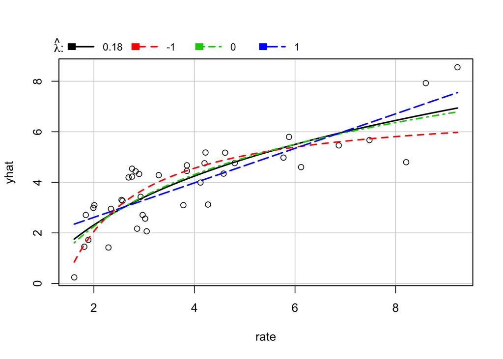

```
##       lambda      RSS
## 1  0.1846179 30.62130
## 2 -1.0000000 34.71600
## 3  0.0000000 30.72613
## 4  1.0000000 32.45792
```

```r
#Highway$sigs1 = (Highway$sigs*Highway$len+1)/Highway$len

m2 <- lm(rate ~ log(len) + log(adt) + log(trks) + shld + log(sigs1) + slim, Highway)

inverseResponsePlot(m2)
```

As with the inverse transformation plot, the values of $RSS$ for the displayed curves are shown in the text window. In the example the value of $\hat{\lambda}=0.18$ minimizes $RSS$, but there is little to distinguish using this value of $\lambda$ from the simpler case of $\lambda=0$, meaning that the fitted curves for these two values of $\lambda$ match the data nearly equally well. The log-transform is therefore suggested.

#### Box-Cox

An alternative to the above is the Box-Cox transformation, this time applied on $Y$. The purpose is make the transformed data close to normal distribution.

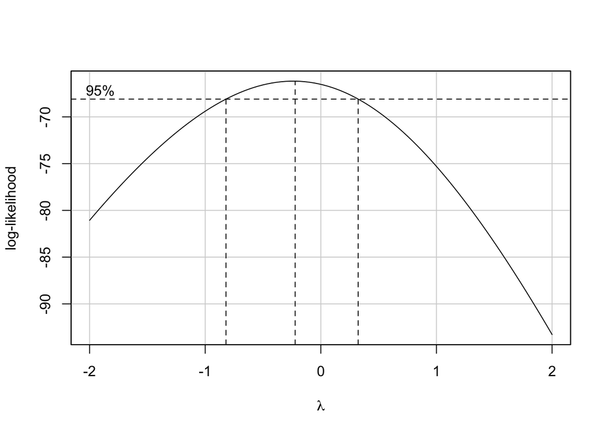

```r
boxCox(m2)
```

We find $\widehat{\lambda}$ that maximizes the likelihood as the above plot shows. We see that $0$ is in the interval again. So the Box-Cox approach also endorses the log transform.

We can get the numerical summary of the plot by

```r
summary(powerTransform(m2))
```

```
## bcPower Transformation to Normality
##    Est.Power Std.Err. Wald Lower Bound Wald Upper Bound
## Y1   -0.2384   0.2891           -0.805           0.3282
##
## Likelihood ratio tests about transformation parameters
##                              LRT df         pval
## LR test, lambda = (0)  0.6884455  1 4.066936e-01
## LR test, lambda = (1) 18.2451001  1 1.942249e-05
```

## Transformations of Nonpositive Variables

1. Consider transformations of the form $(U+\gamma)^{\lambda}$, where $\gamma$ is sufficiently large to ensure that $U+\gamma$ is strictly positive.
2. Yeo and Johnson (2000) proposed a family of transformations that can be used without restrictions on $U$ that have many of the good properties of the Box– Cox power family:
   $$\Psi_{YJ}(U,\lambda)= \left\{
   \begin{array}{ll}
   \Psi_S(U+1,\lambda), & U \geq 0\\
   -\Psi_S(-U+1,2-\lambda) & U<0 \\
   \end{array}
   \right.$$